# Project Boston

Nam Nguyen

2025-04-13

#Import the dataset

– Import the dataset

– Name the column

```r
colnames(housing) <- c('CRIM', 'ZN', 'INDUS', 'CHAS', 'NOX', 'RM', 'AGE', 'DIS', 'RAD', 'TAX',
                                              'PTRATIO', 'B', 'LSTAT', 'MEDV')
head(housing)
```

| CRIM | ZN | INDUS | CHAS | NOX | RM | AGE | DIS | RAD | TAX | PTRATIO | B | LSTAT | MEDV |
| --- | --- | --- | --- | --- | --- | --- | --- | --- | --- | --- | --- | --- | --- |
| 0.00632 | 18 | 2.31 | 0 | 0.538 | 6.575 | 65.2 | 4.0900 | 1 | 296 | 15.3 | 396.90 | 4.98 | 24.0 |
| 0.02731 | 0 | 7.07 | 0 | 0.469 | 6.421 | 78.9 | 4.9671 | 2 | 242 | 17.8 | 396.90 | 9.14 | 21.6 |
| 0.02729 | 0 | 7.07 | 0 | 0.469 | 7.185 | 61.1 | 4.9671 | 2 | 242 | 17.8 | 392.83 | 4.03 | 34.7 |
| 0.03237 | 0 | 2.18 | 0 | 0.458 | 6.998 | 45.8 | 6.0622 | 3 | 222 | 18.7 | 394.63 | 2.94 | 33.4 |
| 0.06905 | 0 | 2.18 | 0 | 0.458 | 7.147 | 54.2 | 6.0622 | 3 | 222 | 18.7 | 396.90 | 5.33 | 36.2 |
| 0.02985 | 0 | 2.18 | 0 | 0.458 | 6.430 | 58.7 | 6.0622 | 3 | 222 | 18.7 | 394.12 | 5.21 | 28.7 |

– Adding labels

```r
library(labelled)
# Set variable labels for the housing dataset
var_label(housing$CRIM) <- "per capita crime rate by town"
var_label(housing$ZN) <- "proportion of residential land zoned for lots over 25,000 sq.ft"
var_label(housing$INDUS) <- "proportion of non-retail business acres per town"
var_label(housing$CHAS) <- "Charles River dummy variable (1 if tract bounds river; 0 otherwise)"
var_label(housing$NOX) <- "nitric oxides concentration (parts per 10 million)"
var_label(housing$RM) <- "average number of rooms per dwelling"
var_label(housing$AGE) <- "proportion of owner-occupied units built prior to 1940"
var_label(housing$DIS) <- "weighted distances to five Boston employment centres"
var_label(housing$RAD) <- "index of accessibility to radial highways"
var_label(housing$TAX) <- "full-value property-tax rate per $10,000"
var_label(housing$PTRATIO) <- "pupil-teacher ratio by town"
var_label(housing$B) <- "1000(Bk - 0.63)^2 where Bk is the proportion of blacks by town"
var_label(housing$LSTAT) <- "% lower status of the population"
var_label(housing$MEDV) <- "Median value of owner-occupied homes in $1000's"
var_label(housing)
```

```
## $CRIM
## [1] "per capita crime rate by town"
##
## $ZN
## [1] "proportion of residential land zoned for lots over 25,000 sq.ft"
##
## $INDUS
## [1] "proportion of non-retail business acres per town"
##
## $CHAS
## [1] "Charles River dummy variable (1 if tract bounds river; 0 otherwise)"
##
## $NOX
## [1] "nitric oxides concentration (parts per 10 million)"
##
## $RM
## [1] "average number of rooms per dwelling"
##
## $AGE
## [1] "proportion of owner-occupied units built prior to 1940"
##
## $DIS
## [1] "weighted distances to five Boston employment centres"
##
## $RAD
## [1] "index of accessibility to radial highways"
##
## $TAX
## [1] "full-value property-tax rate per $10,000"
##
## $PTRATIO
## [1] "pupil-teacher ratio by town"
##
## $B
## [1] "1000(Bk - 0.63)^2 where Bk is the proportion of blacks by town"
##
## $LSTAT
## [1] "% lower status of the population"
##
## $MEDV
## [1] "Median value of owner-occupied homes in $1000's"
```

–Check the variable type

```r
str(housing)
```

```
## spc_tbl_ [506 × 14] (S3: spec_tbl_df/tbl_df/tbl/data.frame)
##  $ CRIM   : num [1:506] 0.00632 0.02731 0.02729 0.03237 0.06905 ...
##   ..- attr(*, "label")= chr "per capita crime rate by town"
##  $ ZN     : num [1:506] 18 0 0 0 0 0 12.5 12.5 12.5 12.5 ...
##   ..- attr(*, "label")= chr "proportion of residential land zoned for lots over 25,000 sq.ft"
##  $ INDUS  : num [1:506] 2.31 7.07 7.07 2.18 2.18 2.18 7.87 7.87 7.87 7.87 ...
##   ..- attr(*, "label")= chr "proportion of non-retail business acres per town"
##  $ CHAS   : num [1:506] 0 0 0 0 0 0 0 0 0 0 ...
##   ..- attr(*, "label")= chr "Charles River dummy variable (1 if tract bounds river; 0 otherwise)"
##  $ NOX    : num [1:506] 0.538 0.469 0.469 0.458 0.458 0.458 0.524 0.524 0.524 0.524 ...
##   ..- attr(*, "label")= chr "nitric oxides concentration (parts per 10 million)"
##  $ RM     : num [1:506] 6.58 6.42 7.18 7 7.15 ...
##   ..- attr(*, "label")= chr "average number of rooms per dwelling"
##  $ AGE    : num [1:506] 65.2 78.9 61.1 45.8 54.2 58.7 66.6 96.1 100 85.9 ...
##   ..- attr(*, "label")= chr "proportion of owner-occupied units built prior to 1940"
##  $ DIS    : num [1:506] 4.09 4.97 4.97 6.06 6.06 ...
##   ..- attr(*, "label")= chr "weighted distances to five Boston employment centres"
##  $ RAD    : num [1:506] 1 2 2 3 3 3 5 5 5 5 ...
##   ..- attr(*, "label")= chr "index of accessibility to radial highways"
##  $ TAX    : num [1:506] 296 242 242 222 222 222 311 311 311 311 ...
##   ..- attr(*, "label")= chr "full-value property-tax rate per $10,000"
##  $ PTRATIO: num [1:506] 15.3 17.8 17.8 18.7 18.7 18.7 15.2 15.2 15.2 15.2 ...
##   ..- attr(*, "label")= chr "pupil-teacher ratio by town"
##  $ B      : num [1:506] 397 397 393 395 397 ...
##   ..- attr(*, "label")= chr "1000(Bk - 0.63)^2 where Bk is the proportion of blacks by town"
##  $ LSTAT  : num [1:506] 4.98 9.14 4.03 2.94 5.33 ...
##   ..- attr(*, "label")= chr "% lower status of the population"
##  $ MEDV   : num [1:506] 24 21.6 34.7 33.4 36.2 28.7 22.9 27.1 16.5 18.9 ...
##   ..- attr(*, "label")= chr "Median value of owner-occupied homes in $1000's"
##  - attr(*, "spec")=
##   .. cols(
##   ..   X1 = col_double(),
##   ..   X2 = col_double(),
##   ..   X3 = col_double(),
##   ..   X4 = col_double(),
##   ..   X5 = col_double(),
##   ..   X6 = col_double(),
##   ..   X7 = col_double(),
##   ..   X8 = col_double(),
##   ..   X9 = col_double(),
##   ..   X10 = col_double(),
##   ..   X11 = col_double(),
##   ..   X12 = col_double(),
##   ..   X13 = col_double(),
##   ..   X14 = col_double()
##   .. )
```

=> All **numeric**

- Check for missing value:

```r
colSums(is.na(housing))
```

```
##    CRIM      ZN   INDUS    CHAS     NOX      RM     AGE     DIS     RAD     TAX
##       0       0       0       0       0       0       0       0       0       0
## PTRATIO       B   LSTAT    MEDV
##       0       0       0       0
```

=> **No missing value**

#Descriptive stats on the data

```r
summary(housing)
```

```
##       CRIM                ZN             INDUS            CHAS
##  Min.   : 0.00632   Min.   :  0.00   Min.   : 0.46   Min.   :0.00000
##  1st Qu.: 0.08205   1st Qu.:  0.00   1st Qu.: 5.19   1st Qu.:0.00000
##  Median : 0.25651   Median :  0.00   Median : 9.69   Median :0.00000
##  Mean   : 3.61352   Mean   : 11.36   Mean   :11.14   Mean   :0.06917
##  3rd Qu.: 3.67708   3rd Qu.: 12.50   3rd Qu.:18.10   3rd Qu.:0.00000
##  Max.   :88.97620   Max.   :100.00   Max.   :27.74   Max.   :1.00000
##       NOX               RM             AGE              DIS
##  Min.   :0.3850   Min.   :3.561   Min.   :  2.90   Min.   : 1.130
##  1st Qu.:0.4490   1st Qu.:5.886   1st Qu.: 45.02   1st Qu.: 2.100
##  Median :0.5380   Median :6.208   Median : 77.50   Median : 3.207
##  Mean   :0.5547   Mean   :6.285   Mean   : 68.57   Mean   : 3.795
##  3rd Qu.:0.6240   3rd Qu.:6.623   3rd Qu.: 94.08   3rd Qu.: 5.188
##  Max.   :0.8710   Max.   :8.780   Max.   :100.00   Max.   :12.127
##       RAD              TAX           PTRATIO            B
##  Min.   : 1.000   Min.   :187.0   Min.   :12.60   Min.   :  0.32
##  1st Qu.: 4.000   1st Qu.:279.0   1st Qu.:17.40   1st Qu.:375.38
##  Median : 5.000   Median :330.0   Median :19.05   Median :391.44
##  Mean   : 9.549   Mean   :408.2   Mean   :18.46   Mean   :356.67
##  3rd Qu.:24.000   3rd Qu.:666.0   3rd Qu.:20.20   3rd Qu.:396.23
##  Max.   :24.000   Max.   :711.0   Max.   :22.00   Max.   :396.90
##      LSTAT            MEDV
##  Min.   : 1.73   Min.   : 5.00
##  1st Qu.: 6.95   1st Qu.:17.02
##  Median :11.36   Median :21.20
##  Mean   :12.65   Mean   :22.53
##  3rd Qu.:16.95   3rd Qu.:25.00
##  Max.   :37.97   Max.   :50.00
```

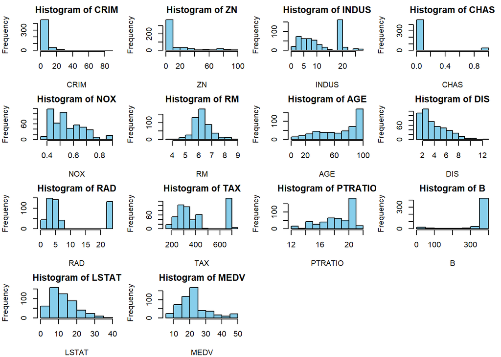

```r
par(mfrow = c(4, 4), mar = c(4, 4, 2, 1))
for (col in colnames(housing)) {
  hist(housing[[col]], main = paste("Histogram of", col), xlab = col, col = "skyblue", border = "black")
}
```

In 1970:

About the infrastructure, the accessibility to the centered areas of Boston were well-developed. However, that to radial highways is in the opposite condition

Some other features worth noticing is that CRIM and ZN are also lied on the left side of the graph, which indicates that the metropolitan areas in Boston were not so well-developed, and the crime rate were low.

– Compare the median value of price by position of Charles

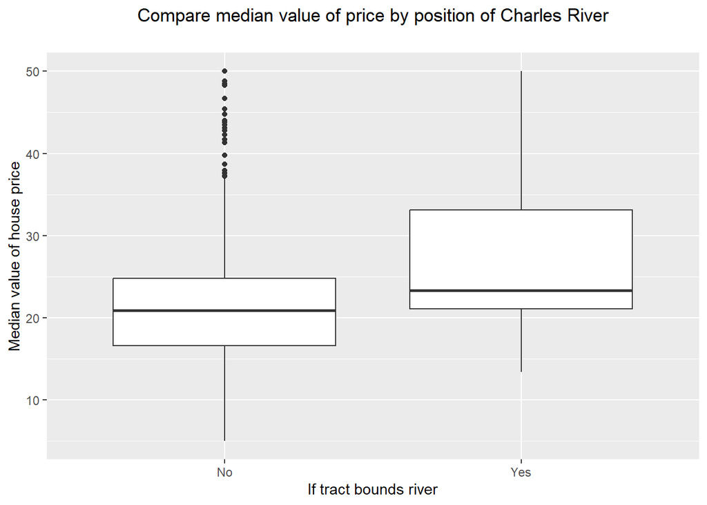

```r
library(ggplot2)
gg1 <- ggplot(housing, aes(factor(CHAS), MEDV)) +
  geom_boxplot() +
  xlab("If tract bounds river") +
  ylab("Median value of house price") +
  ggtitle("Compare median value of price by position of Charles River")
gg1 <- gg1 + theme(plot.title = element_text(hjust = 0.5, margin = margin(b = 20)))
gg1 <- gg1 + scale_x_discrete(labels = c("0" = "No", "1" = "Yes"))
print(gg1)
```

– Compare the proportion of of non-retail by position of Charles

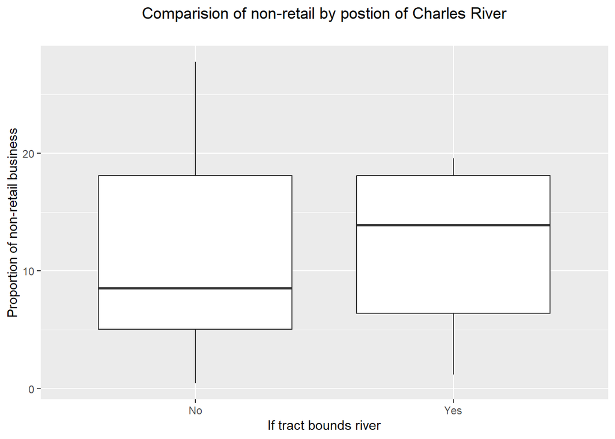

```r
gg <- ggplot(housing, aes(factor(CHAS), INDUS)) +
      geom_boxplot() +
      xlab("If tract bounds river") +
      ylab("Proportion of non-retail business") +
      ggtitle("Comparision of non-retail by postion of Charles River")
gg <- gg + theme(plot.title = element_text(hjust = 0.5, margin = margin(b = 20)))
gg <- gg + scale_x_discrete(labels = c("0" = "No", "1" = "Yes"))
print(gg)
```

– Compare the age group of house

```r
library(dplyr)
```

```r
# Count the unique value in AGE
age_table <- table(housing$AGE)
# Convert the table to a data frame and sort to get the top 10 most frequent ages
top_10_age <- as.data.frame(sort(age_table, decreasing = TRUE)[1:10])
#Change the name of column in table
colnames(top_10_age) <- c("AGE", "Frequency")
# Create a pie chart on age group
# Cut the age into 5 different groups
housing$age_group <- cut(housing$AGE, breaks = c(0, 20, 40, 60, 80, 100),
                         labels = c("1-20", "21-40", "41-60", "61-80", "81-100"), include.lowest = TRUE)
result <- housing %>%
  group_by(age_group) %>%
  summarize(avg_price = mean(MEDV))
print(result)
```

```
## # A tibble: 5 × 2
##   age_group avg_price
##   <fct>         <dbl>
## 1 1-20           27.4
## 2 21-40          27.4
## 3 41-60          24.7
## 4 61-80          23.9
## 5 81-100         19.1
```

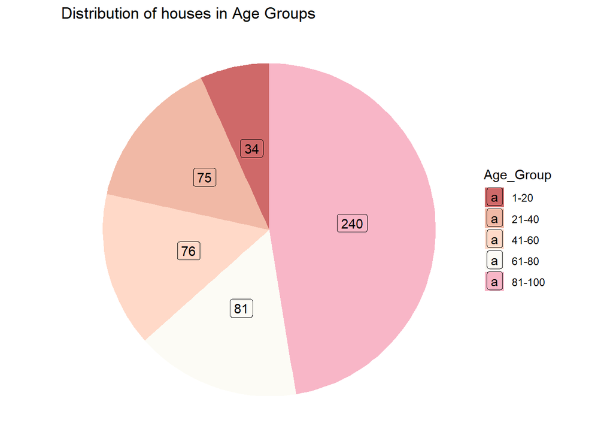

```r
# Count the unique value in age group
age_counts <- table(housing$age_group)
# Convert into dataframe
age_counts_df <- as.data.frame(age_counts)
colnames(age_counts_df) <- c("Age_Group", "Frequency")
#Pie chart
ggplot(age_counts_df, aes(x = "", y = Frequency, fill = Age_Group, label = Frequency)) +
  geom_bar(stat = "identity", width = 1) +
  geom_label(position = position_stack(vjust = 0.5), color = "black") +
  coord_polar("y", start = 0) +
  ggtitle("Distribution of houses in Age Groups") +
  scale_fill_manual(values = c("#CF6969", "#F1B9A6", "#FFD9C8", "#FCFBF5", "#F8B6C7", "#4E6134")) +
  theme_minimal() +
  theme_void()
```

– Correlation

```r
#Correlation test
selected_data <- housing[, c("CRIM", "ZN", "INDUS","NOX","RM","AGE","DIS","RAD","TAX","PTRATIO","B","LSTAT","MEDV")]
correlation_matrix <- cor(selected_data, method = "spearman")
correlation_matrix
```

```
##               CRIM         ZN      INDUS        NOX          RM        AGE
## CRIM     1.0000000 -0.5716602  0.7355237  0.8214647 -0.30911647  0.7041400
## ZN      -0.5716602  1.0000000 -0.6428106 -0.6348284  0.36107373 -0.5444226
## INDUS    0.7355237 -0.6428106  1.0000000  0.7911891 -0.41530129  0.6794867
## NOX      0.8214647 -0.6348284  0.7911891  1.0000000 -0.31034391  0.7951529
## RM      -0.3091165  0.3610737 -0.4153013 -0.3103439  1.00000000 -0.2780820
## AGE      0.7041400 -0.5444226  0.6794867  0.7951529 -0.27808202  1.0000000
## DIS     -0.7449861  0.6146265 -0.7570797 -0.8800149  0.26316822 -0.8016098
## RAD      0.7278070 -0.2787672  0.4555074  0.5864287 -0.10749220  0.4179826
## TAX      0.7290449 -0.3713945  0.6643614  0.6495266 -0.27189846  0.5263664
## PTRATIO  0.4652832 -0.4484754  0.4337105  0.3913091 -0.31292257  0.3553843
## B       -0.3605553  0.1631351 -0.2858398 -0.2966616  0.05366004 -0.2280220
## LSTAT    0.6347603 -0.4900739  0.6387474  0.6368283 -0.64083156  0.6570708
## MEDV    -0.5588909  0.4381790 -0.5782554 -0.5626088  0.63357643 -0.5475617
##                DIS        RAD        TAX     PTRATIO           B      LSTAT
## CRIM    -0.7449861  0.7278070  0.7290449  0.46528319 -0.36055532  0.6347603
## ZN       0.6146265 -0.2787672 -0.3713945 -0.44847543  0.16313510 -0.4900739
## INDUS   -0.7570797  0.4555074  0.6643614  0.43371046 -0.28583984  0.6387474
## NOX     -0.8800149  0.5864287  0.6495266  0.39130908 -0.29666158  0.6368283
## RM       0.2631682 -0.1074922 -0.2718985 -0.31292257  0.05366004 -0.6408316
## AGE     -0.8016098  0.4179826  0.5263664  0.35538428 -0.22802200  0.6570708
## DIS      1.0000000 -0.4958065 -0.5743364 -0.32204056  0.24959532 -0.5642622
## RAD     -0.4958065  1.0000000  0.7048757  0.31832966 -0.28253261  0.3943224
## TAX     -0.5743364  0.7048757  1.0000000  0.45334546 -0.32984308  0.5344232
## PTRATIO -0.3220406  0.3183297  0.4533455  1.00000000 -0.07202734  0.4672588
## B        0.2495953 -0.2825326 -0.3298431 -0.07202734  1.00000000 -0.2105619
## LSTAT   -0.5642622  0.3943224  0.5344232  0.46725885 -0.21056185  1.0000000
## MEDV     0.4458569 -0.3467763 -0.5624106 -0.55590468  0.18566412 -0.8529141
##               MEDV
## CRIM    -0.5588909
## ZN       0.4381790
## INDUS   -0.5782554
## NOX     -0.5626088
## RM       0.6335764
## AGE     -0.5475617
## DIS      0.4458569
## RAD     -0.3467763
## TAX     -0.5624106
## PTRATIO -0.5559047
## B        0.1856641
## LSTAT   -0.8529141
## MEDV     1.0000000
```

Factors such as **residential land proportion, number of rooms, distance to centers, and racial proportion** positively correlate with prices, while **others** show a negative trend.

#Building the Regression model

– build the mlr model

```r
lm <- lm(MEDV ~ CRIM +ZN + INDUS + CHAS + NOX + RM + AGE + DIS + RAD + TAX + PTRATIO + B + LSTAT, data = housing)
summary(lm)
```

```
##
## Call:
## lm(formula = MEDV ~ CRIM + ZN + INDUS + CHAS + NOX + RM + AGE +
##     DIS + RAD + TAX + PTRATIO + B + LSTAT, data = housing)
##
## Residuals:
##     Min      1Q  Median      3Q     Max
## -15.595  -2.730  -0.518   1.777  26.199
##
## Coefficients:
##               Estimate Std. Error t value Pr(>|t|)
## (Intercept)  3.646e+01  5.103e+00   7.144 3.28e-12 ***
## CRIM        -1.080e-01  3.286e-02  -3.287 0.001087 **
## ZN           4.642e-02  1.373e-02   3.382 0.000778 ***
## INDUS        2.056e-02  6.150e-02   0.334 0.738288
## CHAS         2.687e+00  8.616e-01   3.118 0.001925 **
## NOX         -1.777e+01  3.820e+00  -4.651 4.25e-06 ***
## RM           3.810e+00  4.179e-01   9.116  < 2e-16 ***
## AGE          6.922e-04  1.321e-02   0.052 0.958229
## DIS         -1.476e+00  1.995e-01  -7.398 6.01e-13 ***
## RAD          3.060e-01  6.635e-02   4.613 5.07e-06 ***
## TAX         -1.233e-02  3.760e-03  -3.280 0.001112 **
## PTRATIO     -9.527e-01  1.308e-01  -7.283 1.31e-12 ***
## B            9.312e-03  2.686e-03   3.467 0.000573 ***
## LSTAT       -5.248e-01  5.072e-02 -10.347  < 2e-16 ***
## ---
## Signif. codes:  0 '***' 0.001 '**' 0.01 '*' 0.05 '.' 0.1 ' ' 1
##
## Residual standard error: 4.745 on 492 degrees of freedom
## Multiple R-squared:  0.7406, Adjusted R-squared:  0.7338
## F-statistic: 108.1 on 13 and 492 DF,  p-value: < 2.2e-16
```

All given variables explain 74.06% the change of house price in Boston. => Except for Indus, AGE, all variables affected the price of house

– OLS assumption test

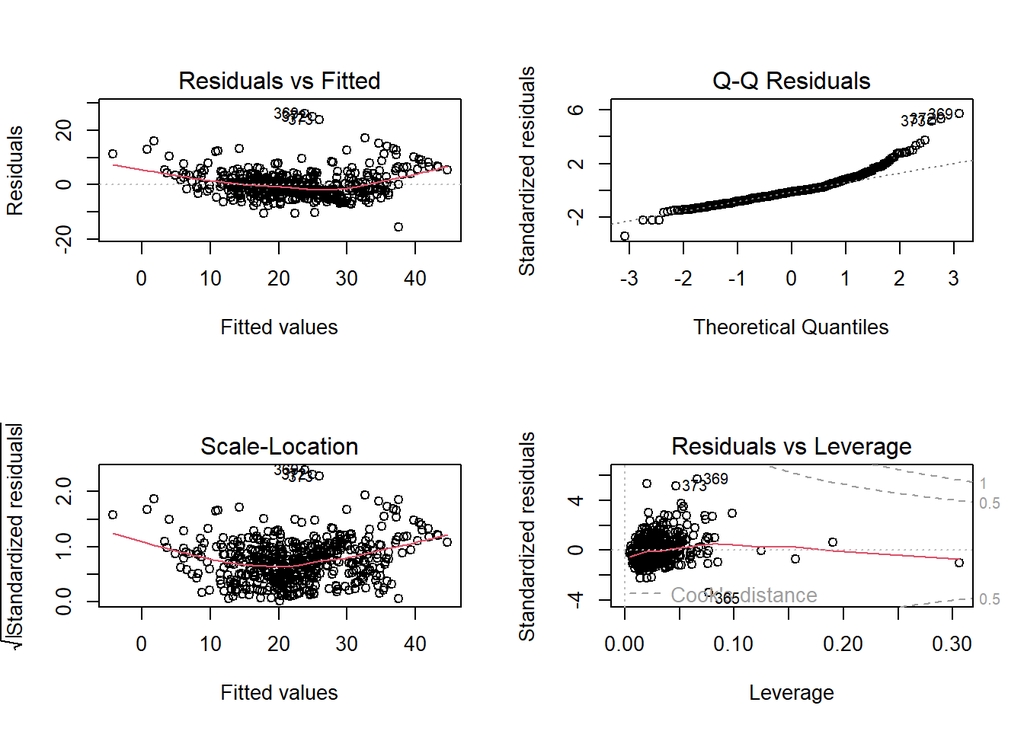

```r
par(mfrow=c(2,2))
plot(lm)
```

it seems like the model has violated normality, use BP test to ensure. the residual does not follow linear

– Homoscedasticity test

```r
library(lmtest)
bptest(lm)
```

```
##
##  studentized Breusch-Pagan test
##
## data:  lm
## BP = 65.122, df = 13, p-value = 6.265e-09
```

– Durbin-watson test for independence of errors

```r
library(car)
dw_result <- durbinWatsonTest(lm)
dw_result
```

```
##  lag Autocorrelation D-W Statistic p-value
##    1       0.4542626      1.078375       0
##  Alternative hypothesis: rho != 0
```

=> Violated

– Normality test of residuals:

```r
residuals <- residuals(lm)
ks_result <- ks.test(residuals, "pnorm")
print(ks_result)
```

```
##
##  Asymptotic one-sample Kolmogorov-Smirnov test
##
## data:  residuals
## D = 0.33286, p-value < 2.2e-16
## alternative hypothesis: two-sided
```

– Multicollinearity

```r
vif_values <- vif(lm)
vif_values
```

```
##     CRIM       ZN    INDUS     CHAS      NOX       RM      AGE      DIS
## 1.792192 2.298758 3.991596 1.073995 4.393720 1.933744 3.100826 3.955945
##      RAD      TAX  PTRATIO        B    LSTAT
## 7.484496 9.008554 1.799084 1.348521 2.941491
```

all < 10, so no Multicollinearity violated

– compare the beta coef

```r
library(lm.beta)
beta_coefs <- lm.beta(lm)
beta_coefs
```

```
##
## Call:
## lm(formula = MEDV ~ CRIM + ZN + INDUS + CHAS + NOX + RM + AGE +
##     DIS + RAD + TAX + PTRATIO + B + LSTAT, data = housing)
##
## Standardized Coefficients::
##  (Intercept)         CRIM           ZN        INDUS         CHAS          NOX
##           NA -0.101017076  0.117715201  0.015335200  0.074198832 -0.223848028
##           RM          AGE          DIS          RAD          TAX      PTRATIO
##  0.291056465  0.002118638 -0.337836347  0.289749053 -0.226031680 -0.224271231
##            B        LSTAT
##  0.092432232 -0.407446933
```

compare the absolute value (Except for Indus, AGE) => **LSTAT, DIS, RM** seem to have the biggest effect on the house price in Boston (1970)

#KNN Regression

Since the dataset is all numeric, so I used the Knn regression

– data normalization

```r
library(caret)
library(dplyr)
housing1 <- preProcess(housing, method = "center", "scale")
housingfinal <- predict(housing1, housing)
```

– Divide the dataset into training set and test set

```r
set.seed(123)
training <- createDataPartition(housing$MEDV, p=0.8, list = FALSE)
training_set <- slice(housingfinal, training)
test_set <- slice(housingfinal, -training)
```

– Train the knn model

```r
best_knn <- train(MEDV~CRIM + ZN + INDUS + CHAS + NOX + RM + AGE + DIS + RAD + TAX + PTRATIO + B +LSTAT, training_set, #Predict the med value from other variables, method = Cross-validation
method="knn",
na.action = na.omit,
tuneLength = 10)
```

– Choose the best knn

```r
best_knn
```

```
## k-Nearest Neighbors
##
## 407 samples
##  13 predictor
##
## No pre-processing
## Resampling: Bootstrapped (25 reps)
## Summary of sample sizes: 407, 407, 407, 407, 407, 407, ...
## Resampling results across tuning parameters:
##
##   k   RMSE      Rsquared   MAE
##    5  7.015831  0.4384692  4.835721
##    7  7.042662  0.4207058  4.860388
##    9  7.102965  0.4061625  4.920131
##   11  7.109922  0.4002251  4.908904
##   13  7.145837  0.3915569  4.912798
##   15  7.215540  0.3782094  4.961485
##   17  7.270669  0.3685219  4.983887
##   19  7.315741  0.3602793  5.021235
##   21  7.359997  0.3517479  5.074916
##   23  7.418352  0.3415619  5.131217
##
## RMSE was used to select the optimal model using the smallest value.
## The final value used for the model was k = 5.
```

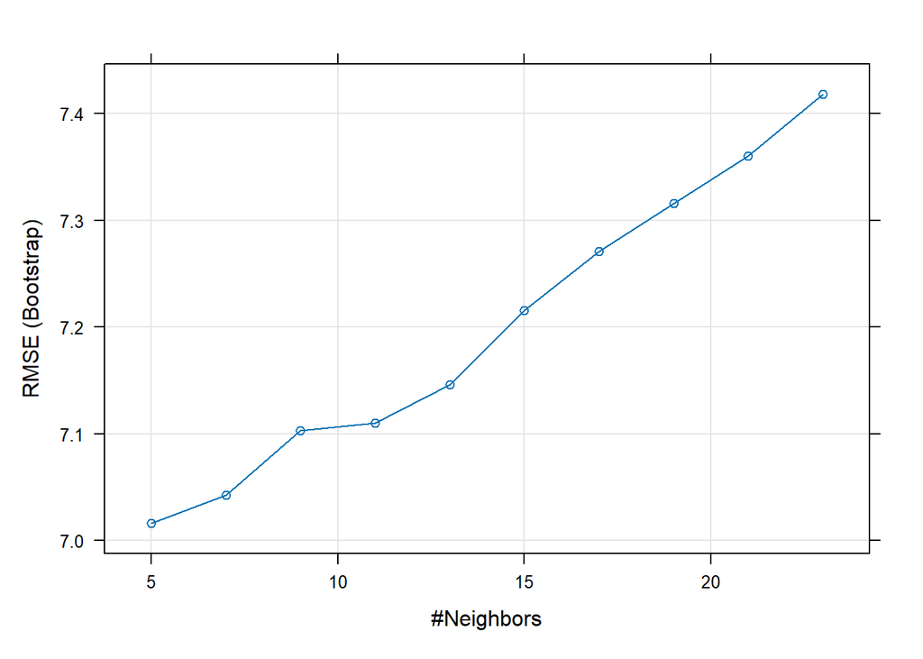

```r
plot(best_knn)
```

```r
best_knn$bestTune
```

|  | k |
| --- | --- |
| 1 | 5 |

=> **K = 5 is the best**

```r
predicted.classes <- predict(best_knn, test_set)
y_test <- test_set$MEDV
data.frame(y_test, predicted.classes)
```

| y_test | predicted.classes |
| --- | --- |
| 12.16719368 | -0.61280632 |
| 6.16719368 | 2.72719368 |
| -6.03280632 | -3.37280632 |
| -7.53280632 | -2.09280632 |
| -2.13280632 | -0.03280632 |
| -4.33280632 | 4.82719368 |
| -9.83280632 | -3.35280632 |
| -8.03280632 | -5.49280632 |
| -3.63280632 | 5.12719368 |
| 12.36719368 | 13.00719368 |

[output cut: 89 more lines]

```r
mse = mean((y_test - predicted.classes)^2)
mae = caret::MAE(y_test, predicted.classes)
rmse = caret::RMSE(y_test, predicted.classes)
cat("MSE: ", mse, "MAE: ", mae, " RMSE: ", rmse)
```

```
## MSE:  34.2586 MAE:  4.270505  RMSE:  5.853084
```

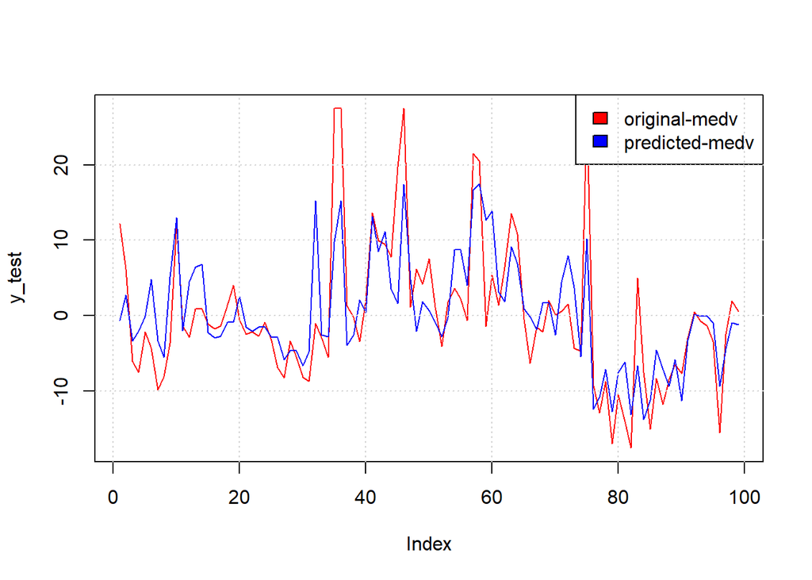

```r
plot(y_test, col = "red", type = "l") # Draw y_test as line
lines(predicted.classes, col = "blue") # Draw predicted.classes
legend("topright", legend = c("original-medv", "predicted-medv"), fill = c("red", "blue"))
grid()
```

**k = 5 is moderately accurate**

*Note: This file I used just for practicing statistical methods on Rstudio. So, the model is for reference purpose only and based on the train and test set every individual has. For more accurate method, we can use the loop fucntion.*